# Ecuaciones de Campo Medio

### Comparación periódico con campo medio

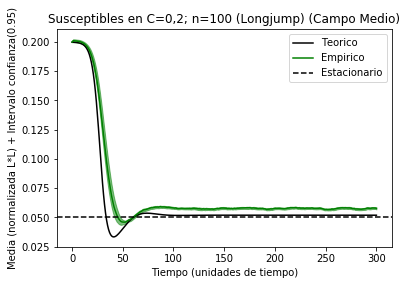

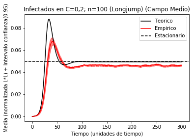

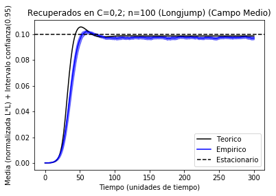

| Variable | Teorico | Ecuaciones | Simulado | Diferencia | Poblacion dieferencia |
| --- | --- | --- | --- | --- | --- |
| Susceptibles | 0.0500 | 0.0519 | 0.0577 | -0.0059 | -58.5407 |
| Infectados | 0.0500 | 0.0494 | 0.0464 | 0.0030 | 29.9402 |
| Recuperados | 0.1000 | 0.0987 | 0.0971 | 0.0016 | 16.0605 |

```python
L = 100
C = 0.2
a = pr
b = ps

S = [((L*L*C)-1)/(L*L)]
I = [1/(L*L)]
R = [0]

n = 4
Sest = a/(n*p)
Iest = (C - (a/(n*p)))/(1+(a/b))
Rest = (a*(C - (a/(n*p))))/(a+b)

for t in range(0, 300):
    S.append(S[t] - S[t]*(1-(1-p*I[t])**4) + b*R[t])

    I.append(I[t] + S[t]*(1-(1-p*I[t])**4) - a*I[t])

    R.append(R[t] + a*I[t] - b*R[t])

plt.plot(S, "k")
plt.fill_between(range(stats6["s_means"].shape[0]), stats6["s_end"], stats6["s_start"], color='g', alpha=0.5)
plt.plot(stats6["s_means"], color='g')
plt.axhline(y=Sest, color='k', linestyle='--')
plt.xlabel('Tiempo (unidades de tiempo)')
plt.ylabel('Media (normalizada L*L) + Intervalo confianza(0.95)')
plt.title('Susceptibles en C=0,2; n=100 (Longjump) (Campo Medio)')
plt.legend(['Teorico','Empirico', 'Estacionario'])
plt.show()

plt.plot(I, "k")
plt.fill_between(range(stats6["i_means"].shape[0]), stats6["i_end"], stats6["i_start"], color='r', alpha=0.5)
plt.plot(stats6["i_means"], color='r')
plt.axhline(y=Iest, color='k', linestyle='--')
plt.xlabel('Tiempo (unidades de tiempo)')
plt.ylabel('Media (normalizada L*L) + Intervalo confianza(0.95)')
plt.title('Infectados en C=0,2; n=100 (Longjump) (Campo Medio)')
plt.legend(['Teorico','Empirico', 'Estacionario'])
plt.show()

plt.plot(R, "k")
plt.fill_between(range(stats6["r_means"].shape[0]), stats6["r_end"], stats6["r_start"], color='b', alpha=0.5)
plt.plot(stats6["r_means"], color='b')
plt.axhline(y=Rest, color='k', linestyle='--')
plt.xlabel('Tiempo (unidades de tiempo)')
plt.ylabel('Media (normalizada L*L) + Intervalo confianza(0.95)')
plt.title('Recuperados en C=0,2; n=100 (Longjump) (Campo Medio)')
plt.legend(['Teorico','Empirico', 'Estacionario'])
plt.show()

salida = "<table><tr><th>Variable</th><th>Teorico</th><th>Ecuaciones</th><th>Simulado</th><th>Diferencia</th><th>Poblacion dieferencia</th></tr>"
salida += "<tr><td>Susceptibles</td><td>%.4f</td><td>%.4f</td><td>%.4f</td><td>%.4f</td><td>%.4f</td></tr>" % (Sest, S[-1],stats6["s_means"][-1],S[-1]-stats6["s_means"][-1], (S[-1]-stats6["s_means"][-1])*(L*L))
salida += "<tr><td>Infectados</td><td>%.4f</td><td>%.4f</td><td>%.4f</td><td>%.4f</td><td>%.4f</td></tr>" % (Iest, I[-1],stats6["i_means"][-1],I[-1]-stats6["i_means"][-1], (I[-1]-stats6["i_means"][-1])*(L*L))
salida += "<tr><td>Recuperados</td><td>%.4f</td><td>%.4f</td><td>%.4f</td><td>%.4f</td><td>%.4f</td></tr>" % (Rest, R[-1],stats6["r_means"][-1],R[-1]-stats6["r_means"][-1], (R[-1]-stats6["r_means"][-1])*(L*L))
salida += "</table>"
display(HTML(salida))
```

En este caso, al igual que en los ateriores, el error permanece igual.

Como se puede ver, hemos añadido a las gráficas una linea horizontal que nos marca el valor esperado teórico para cada una de las poblaciones en estado estacionario.

### Relación Infectados/Recuperados

A la hora de calcular las ecuaciones para el valor esperado en estado estacionario, hemos descubierto una relacion entre el valor esperado para los infectados y los recuperados.

[output not shown]

De esta forma, sabiendo el valor del cociente (a/b), obtenemos una forma de validar nuestros datos frente a lo esperado teóricamente:

```python
print("Valor (a/b):",(a/b))
print("Valor para las ecuaciones de campo medio:" ,R[-1]/I[-1])
print("Valor para nuestra simulacion:",stats6["r_means"][-1]/stats6["i_means"][-1])
```

```
Valor (a/b): 2.0
Valor para las ecuaciones de campo medio: 2.000000001275582
Valor para nuestra simulacion: 2.0944885285492494
```

Como vemos, los valores para el esperado y el campo medio son practicamente iguales. En cambio en nuestra simulación nos encontramos con un error de aproximadamente 0.09, de donde probablemente provenga el error encontrado hasta ahora.

Ya por último, hemos decidido imprimir un par de gráficas para ver el comportamiento que siguen los recuperados con respecto a los infectados en el sitema.

En la primera de las gráficas tenemos a trayectoria que sigue para las ecuaciones de campo medio. En la segunda tenemos la trayectoria para instantes de tiempo de 100 en adelante, para ver como se comporta en el estado estacionario. Como vemos, sigue una trayectoria igual, pero si nos fijamos en los valores en los ejes, estos varían en un orden muy pequeño, por lo que, si hacemos caso de la teoría, en el estado estacionario la gráfica tiene que salir muy cercana a un punto.

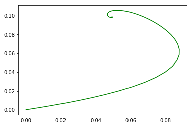

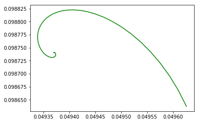

```python
plt.plot(I,R,color='g' )
plt.show()
plt.plot(I[100:],R[100:],color='g' )
plt.show()
```

# Diagrama de fase

## Ecuaciones de campo medio

Primero vamos a determinar cual es la proporción de infectados y susceptibles que determina el punto crítico en nuestro modelo epidémico para contruir el diagrama de fases. Para ello, recogemos la salida de una simulación generada por ecuaciones de campo y vemos la proporción al final de la simulación:

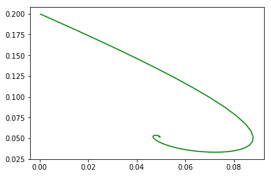

```
Estado estacionario y punto crítico empirico = (0.04937002285976367 Infectados Normalizados   0.05188993126578037 Susceptibles Normalizados)
Estado estacionario y punto crítico teorico = (0.05000000000000001 Infectados Normalizados   0.05 Susceptibles Normalizados)
Número Infectados / Número Susceptibles (Con L=50) => PC = (123.42505714940917 infectados , 129.7248281644509 susceptibles)
Porcentaje Infectados = 0.24685011429881834
Porcentaje Susceptibles = 0.2594496563289018
```

```python
L = 50
C = 0.2
a = pr
b = ps

S = [((L*L*C)-1)/(L*L)]
I = [1/(L*L)]
R = [0]

n = 4
Sest = a/(n*p)
Iest = (C - (a/(n*p)))/(1+(a/b))
Rest = (a*(C - (a/(n*p))))/(a+b)

for t in range(0, 300):
    S.append(S[t] - S[t]*(1-(1-p*I[t])**4) + b*R[t])

    I.append(I[t] + S[t]*(1-(1-p*I[t])**4) - a*I[t])

    R.append(R[t] + a*I[t] - b*R[t])


plt.plot(I,S,color='g')



plt.show()

print("Estado estacionario y punto crítico empirico = (" + str(I[-1]) + " Infectados Normalizados   " + str(S[-1]) + " Susceptibles Normalizados)")

print("Estado estacionario y punto crítico teorico = (" + str(Iest) + " Infectados Normalizados   " + str(Sest) + " Susceptibles Normalizados)")

print("Número Infectados / Número Susceptibles (Con L=50) => PC = (" + str(I[-1]*L*L) + " infectados , " + str(S[-1]*L*L) +" susceptibles) ")

print("Porcentaje Infectados = " + str((I[-1]*L*L)/(L*L*C)))

print("Porcentaje Susceptibles = " + str((S[-1]*L*L)/(L*L*C)))
```

Como vemos en la gráfica y en los resultados de la simulación, el punto crítico al realizar la simulación son las coordenadas de infectados normalizados respecto susceptibles normalizados es bastante cercado al punto crítico teórico. La proporción es de 24.7 % de infectados y un 26% de susceptibles.

Realizamos el diagrama de fases con simulaciones que cumplen que la suma de infectados y susceptibles iniciales es L·L·C:

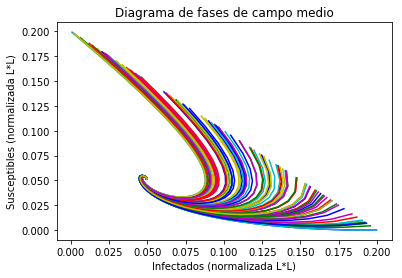

```python
from math import *
import random


L = 50
C = 0.2
a = pr
b = ps

radio = ((L*L*C)/2 - 1)
n_sims = 100
time_sim = 600

R = [0]
colors =['g', 'b', 'r', 'y', 'c', 'm']
n = 4

S_iniciales = []
I_iniciales = []

for _ in range(n_sims):
  susceptibles = ((L*L*C)/2) + random.randint(-radio, radio)
  infectados = ((L*L*C)) - susceptibles
  S_iniciales += [susceptibles/(L*L)]
  I_iniciales += [infectados/(L*L)]


for i in range(len(S_iniciales)):
  S = [S_iniciales[i]]
  I = [I_iniciales[i]]
  R = [0]
  for t in range(0, time_sim):
      S.append(S[t] - S[t]*(1-(1-p*I[t])**4) + b*R[t])

      I.append(I[t] + S[t]*(1-(1-p*I[t])**4) - a*I[t])

      R.append(R[t] + a*I[t] - b*R[t])


  plt.plot(I,S,color=colors[i % len(colors)])

plt.xlabel('Infectados (normalizada L*L)')
plt.ylabel('Susceptibles (normalizada L*L)')
plt.title('Diagrama de fases de campo medio')

plt.show()
```

Como se puede ver, todas las simulaciones tienden al mismo punto crítico que coincide con el estado estacionario teórico (0.05, 0.05)

## Simulaciones Empíricas con Long Jump

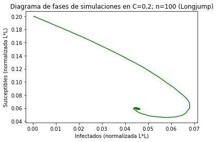

```
Estado estacionario y punto crítico empirico = (0.045056000000000006 Infectados Normalizados   0.06034 Susceptibles Normalizados)
Número Infectados / Número Susceptibles (Con L=50) => PC = (112.64 infectados , 150.85 susceptibles)
Porcentaje Infectados = 0.22528
Porcentaje Susceptibles = 0.30169999999999997
```

```python
stats_df = collectData("NEWESs100t600c02l50LJLL.npy")

I = stats_df["i_means"]
S = stats_df["s_means"]
plt.plot(I, S, color='g')
plt.xlabel('Infectados (normalizada L*L)')
plt.ylabel('Susceptibles (normalizada L*L)')
plt.title('Diagrama de fases de simulaciones en C=0,2; n=100 (Longjump)')
plt.show()

print("Estado estacionario y punto crítico empirico = (" + str(I[-1]) + " Infectados Normalizados   " + str(S[-1]) + " Susceptibles Normalizados)")

print("Número Infectados / Número Susceptibles (Con L=50) => PC = (" + str(I[-1]*L*L) + " infectados , " + str(S[-1]*L*L) +" susceptibles) ")

print("Porcentaje Infectados = " + str((I[-1]*L*L)/(L*L*C)))

print("Porcentaje Susceptibles = " + str((S[-1]*L*L)/(L*L*C)))
```

## Simulaciones empíricas sin Long Jump

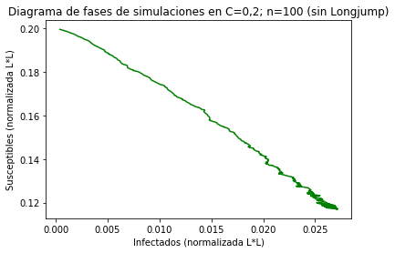

```
Estado estacionario y punto crítico empirico = (0.02656799999999999 Infectados Normalizados   0.11770400000000002 Susceptibles Normalizados)
Número Infectados / Número Susceptibles (Con L=50) => PC = (66.41999999999997 infectados , 294.26000000000005 susceptibles)
Porcentaje Infectados = 0.13283999999999996
Porcentaje Susceptibles = 0.58852
```

```python
stats_df = collectData("NEWESs100t600c02l50.npy")

I = (stats_df["i_means"]*(L*L*C))/(L*L)
S = (stats_df["s_means"]*(L*L*C))/(L*L)
plt.plot(I, S, color='g')
plt.xlabel('Infectados (normalizada L*L)')
plt.ylabel('Susceptibles (normalizada L*L)')
plt.title('Diagrama de fases de simulaciones en C=0,2; n=100 (sin Longjump)')
plt.show()

print("Estado estacionario y punto crítico empirico = (" + str(I[-1]) + " Infectados Normalizados   " + str(S[-1]) + " Susceptibles Normalizados)")

print("Número Infectados / Número Susceptibles (Con L=50) => PC = (" + str(I[-1]*L*L) + " infectados , " + str(S[-1]*L*L) +" susceptibles) ")

print("Porcentaje Infectados = " + str((I[-1]*L*L)/(L*L*C)))

print("Porcentaje Susceptibles = " + str((S[-1]*L*L)/(L*L*C)))
```

### Comparacion LJ vs Periodica

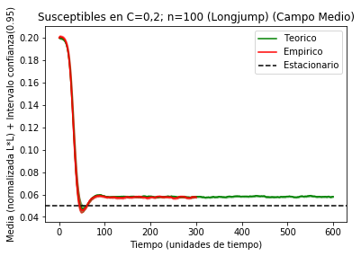

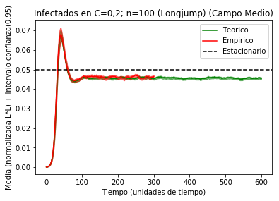

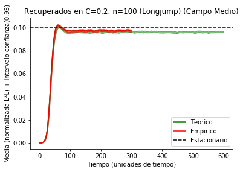

```python
plt.fill_between(range(stats5["s_means"].shape[0]), stats5["s_end"], stats5["s_start"], color='g', alpha=0.5)
plt.plot(stats5["s_means"], color='g')
plt.fill_between(range(stats6["s_means"].shape[0]), stats6["s_end"], stats6["s_start"], color='r', alpha=0.5)
plt.plot(stats6["s_means"], color='r')
plt.axhline(y=Sest, color='k', linestyle='--')
plt.xlabel('Tiempo (unidades de tiempo)')
plt.ylabel('Media (normalizada L*L) + Intervalo confianza(0.95)')
plt.title('Susceptibles en C=0,2; n=100 (Longjump) (Campo Medio)')
plt.legend(['Teorico','Empirico', 'Estacionario'])
plt.show()

plt.fill_between(range(stats5["i_means"].shape[0]), stats5["i_end"], stats5["i_start"], color='g', alpha=0.5)
plt.plot(stats5["i_means"], color='g')
plt.fill_between(range(stats6["i_means"].shape[0]), stats6["i_end"], stats6["i_start"], color='r', alpha=0.5)
plt.plot(stats6["i_means"], color='r')
plt.axhline(y=Iest, color='k', linestyle='--')
plt.xlabel('Tiempo (unidades de tiempo)')
plt.ylabel('Media (normalizada L*L) + Intervalo confianza(0.95)')
plt.title('Infectados en C=0,2; n=100 (Longjump) (Campo Medio)')
plt.legend(['Teorico','Empirico', 'Estacionario'])
plt.show()

plt.fill_between(range(stats5["r_means"].shape[0]), stats5["r_end"], stats5["r_start"], color='g', alpha=0.5)
plt.plot(stats6["r_means"], color='g')
plt.fill_between(range(stats6["r_means"].shape[0]), stats6["r_end"], stats6["r_start"], color='r', alpha=0.5)
plt.plot(stats6["r_means"], color='r')
plt.axhline(y=Rest, color='k', linestyle='--')
plt.xlabel('Tiempo (unidades de tiempo)')
plt.ylabel('Media (normalizada L*L) + Intervalo confianza(0.95)')
plt.title('Recuperados en C=0,2; n=100 (Longjump) (Campo Medio)')
plt.legend(['Teorico','Empirico', 'Estacionario'])
plt.show()
```

## Comparacion diagrame de fases teorico vs empirico

```python
from math import *
import random


L = 50
C = 0.2
a = pr
b = ps

radio = ((L*L*C)/2 - 1)
n_sims = 4
time_sim = 600

R = [0]
colors =['g', 'b', 'r', 'y', 'c', 'm']
n = 4

S_iniciales = [0.18,0.12,0.06,0.02,0.031,0.056,0.01]
I_iniciales = [0.02,0.08,0.14,0.18,0.05,0.025,0.005]

for i in range(len(S_iniciales)):
  S = [S_iniciales[i]]
  I = [I_iniciales[i]]
  R = [0]
  for t in range(0, time_sim):
      S.append(S[t] - S[t]*(1-(1-p*I[t])**4) + b*R[t])

      I.append(I[t] + S[t]*(1-(1-p*I[t])**4) - a*I[t])

      R.append(R[t] + a*I[t] - b*R[t])


  plt.plot(I,S,color=colors[i % len(colors)])
plt.xlabel('Infectados (normalizada L*L)')
plt.ylabel('Susceptibles (normalizada L*L)')
plt.title('Diagrama de fases campo medio 2D')
plt.show()
```

[output not shown]

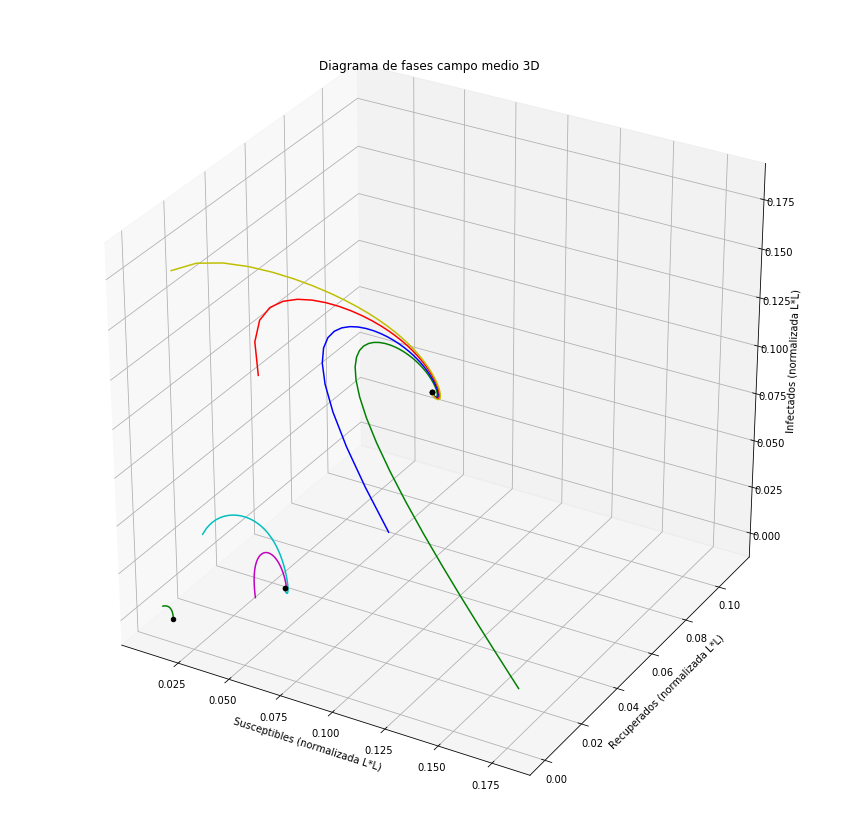

```python
from math import *
import random


L = 50
C = 0.2
a = pr
b = ps

radio = ((L*L*C)/2 - 1)
n_sims = 4
time_sim = 600

R = [0]
colors =['g', 'b', 'r', 'y', 'c', 'm']
n = 4

S_iniciales = [0.18,0.12,0.06,0.02,0.031,0.056,0.01]
I_iniciales = [0.02,0.08,0.14,0.18,0.05,0.025,0.005]

fig = plt.figure(figsize=(15,15))
ax = fig.gca(projection='3d')


for i in range(len(S_iniciales)):
  S = [S_iniciales[i]]
  I = [I_iniciales[i]]
  R = [0]
  for t in range(0, time_sim):
      S.append(S[t] - S[t]*(1-(1-p*I[t])**4) + b*R[t])

      I.append(I[t] + S[t]*(1-(1-p*I[t])**4) - a*I[t])

      R.append(R[t] + a*I[t] - b*R[t])

  ax.scatter(S[-1],R[-1],I[-1], color='k')
  ax.plot(S,R,I,color=colors[i % len(colors)])
ax.set_xlabel('Susceptibles (normalizada L*L)')
ax.set_ylabel('Recuperados (normalizada L*L)')
ax.set_zlabel('Infectados (normalizada L*L)')

plt.title('Diagrama de fases campo medio 3D')
plt.show()
```

```python
nsimulaciones = 50
max_time=300
L=50
C = [0.18,0.12,0.06,0.02,0.031,0.056]
I = [50,200,350,450,125,62]
p=0.5
pr=0.1
ps=0.05
periodic = True
longjump = True
normLL = True

np.random.seed(seed=None)  # seed for reproducibility
stats = np.array([],dtype=float)
stats2 = np.array([],dtype=float)
stats3 = np.array([],dtype=float)

tiemposBreak = []
indicesBreak = []

n = 0
for i in range(0, len(C)):
    np.random.seed(seed=None)  # seed for reproducibility
    stats = np.array([],dtype=float)
    stats2 = np.array([],dtype=float)
    stats3 = np.array([],dtype=float)


    tiemposBreak = []
    indicesBreak = []
    while n < nsimulaciones:

        print("Simulacion",i,":",str(n+1))
        evolution_infected, evolution_susceptible, evolution_recovered = simulation2(max_time, C[i], L, p, pr, ps, periodic, longjump, normLL, I[i])
        if i != 6:
            if len(evolution_infected) >= max_time:
              if n == 0:
                stats = np.append(stats, evolution_susceptible)
                stats2 = np.append(stats2, evolution_infected)
                stats3 = np.append(stats3, evolution_recovered)
              else:
                stats = np.vstack((stats,evolution_susceptible))
                stats2 = np.vstack((stats2,evolution_infected))
                stats3 = np.vstack((stats3,evolution_recovered))
              n += 1
        else:
          if n == 0:
            stats = np.append(stats, evolution_susceptible)
            stats2 = np.append(stats2, evolution_infected)
            stats3 = np.append(stats3, evolution_recovered)
          else:
            stats = np.vstack((stats,evolution_susceptible))
            stats2 = np.vstack((stats2,evolution_infected))
            stats3 = np.vstack((stats3,evolution_recovered))
          n += 1

    statsTotal = np.stack((stats,stats2,stats3), axis = 0)

    np.save("PeriodicFasesC"+str(C[i])+"I"+str(I[i]), statsTotal)
    n=0
```

[output not shown]

[output cut: 279 more lines]

[output not shown]

```python
nsimulaciones = 50
max_time=300
L=50
C = 0.01
I = 12
p=0.5
pr=0.1
ps=0.05
periodic = True
longjump = True
normLL = True

np.random.seed(seed=None)  # seed for reproducibility
stats = np.array([],dtype=float)
stats2 = np.array([],dtype=float)
stats3 = np.array([],dtype=float)

tiemposBreak = []
indicesBreak = []
for n in range(0, nsimulaciones):
	print("Simulacion",str(n+1))
	evolution_infected, evolution_susceptible, evolution_recovered = simulation2(max_time, C, L, p, pr, ps, periodic, longjump, normLL, I)
	if len(evolution_infected) < max_time:
		#indicesBreak.append(n)
		#tiemposBreak.append(len(evolution_infected))
		zeros = np.zeros((max_time+1)-len(evolution_infected))
		zeros2 = np.append(np.asarray(evolution_infected), zeros)
		evolution_infected = zeros2.tolist()

		zeros = np.zeros((max_time+1)-len(evolution_susceptible))
		zeros2 = np.append(np.asarray(evolution_susceptible), zeros)
		evolution_susceptible = zeros2.tolist()

		zeros = np.zeros((max_time+1)-len(evolution_recovered))
		zeros2 = np.append(np.asarray(evolution_recovered), zeros)
		evolution_recovered = zeros2.tolist()
	#print(evolution_infected)
	if n == 0:
		stats = np.append(stats, evolution_susceptible)
		stats2 = np.append(stats2, evolution_infected)
		stats3 = np.append(stats3, evolution_recovered)
	else:
		stats = np.vstack((stats,evolution_susceptible))
		stats2 = np.vstack((stats2,evolution_infected))
		stats3 = np.vstack((stats3,evolution_recovered))

statsTotal = np.stack((stats,stats2,stats3), axis = 0)

np.save("PeriodicFasesC"+str(C)+"I"+str(I), statsTotal)
```

[output not shown]

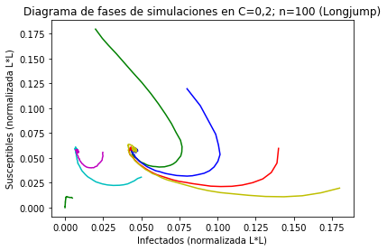

```python
Cs = [0.18,0.12,0.06,0.02,0.031,0.056,0.01]
Is = [50,200,350,450,125,62,12]
colors =['g', 'b', 'r', 'y', 'c', 'm']
for i in range(0,len(Cs)):
    stats_df = collectData("PeriodicFasesC"+str(Cs[i])+"I"+str(Is[i])+".npy")

    I = stats_df["i_means"]
    S = stats_df["s_means"]
    plt.plot(I, S, color=colors[i % len(colors)])

plt.xlabel('Infectados (normalizada L*L)')
plt.ylabel('Susceptibles (normalizada L*L)')
plt.title('Diagrama de fases de simulaciones en C=0,2; n=100 (Longjump)')
plt.show()
```

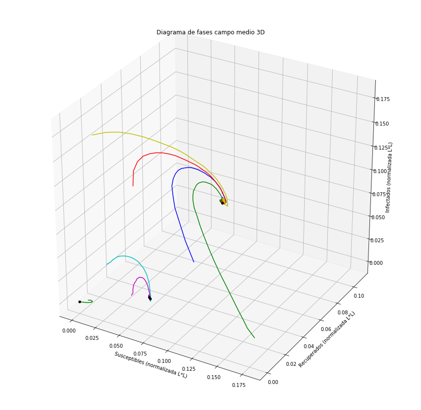

```python
Cs = [0.18,0.12,0.06,0.02,0.031,0.056,0.01]
Is = [50,200,350,450,125,62,12]
colors =['g', 'b', 'r', 'y', 'c', 'm']

fig = plt.figure(figsize=(15,15))
ax = fig.gca(projection='3d')

for i in range(0,len(Cs)):
    stats_df = collectData("PeriodicFasesC"+str(Cs[i])+"I"+str(Is[i])+".npy")

    I = stats_df["i_means"]
    S = stats_df["s_means"]
    R = stats_df["r_means"]
    ax.scatter(S[-1],R[-1],I[-1], color='k')
    ax.plot(S,R,I,color=colors[i % len(colors)])

ax.set_xlabel('Susceptibles (normalizada L*L)')
ax.set_ylabel('Recuperados (normalizada L*L)')
ax.set_zlabel('Infectados (normalizada L*L)')

plt.title('Diagrama de fases campo medio 3D')
plt.show()
```

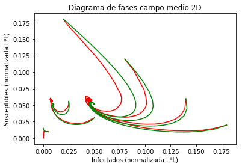

```
Rojo: Empirico
Verde: Teorico
```

```python
from math import *
import random

Cs = [0.18,0.12,0.06,0.02,0.031,0.056,0.01]
Is = [50,200,350,450,125,62,12]
for i in range(0,len(Cs)):
    stats_df = collectData("PeriodicFasesC"+str(Cs[i])+"I"+str(Is[i])+".npy")

    I = stats_df["i_means"]
    S = stats_df["s_means"]
    plt.plot(I, S, color='r')



L = 50
C = 0.2
a = pr
b = ps

radio = ((L*L*C)/2 - 1)
n_sims = 4
time_sim = 600

R = [0]
n = 4

S_iniciales = [0.18,0.12,0.06,0.02,0.031,0.056,0.01]
I_iniciales = [0.02,0.08,0.14,0.18,0.05,0.025,0.005]

for i in range(len(S_iniciales)):
  S = [S_iniciales[i]]
  I = [I_iniciales[i]]
  R = [0]
  for t in range(0, time_sim):
      S.append(S[t] - S[t]*(1-(1-p*I[t])**4) + b*R[t])

      I.append(I[t] + S[t]*(1-(1-p*I[t])**4) - a*I[t])

      R.append(R[t] + a*I[t] - b*R[t])


  plt.plot(I,S,color='g')
plt.xlabel('Infectados (normalizada L*L)')
plt.ylabel('Susceptibles (normalizada L*L)')
plt.title('Diagrama de fases campo medio 2D')
plt.show()
print("Rojo: Empirico")
print("Verde: Teorico")
```

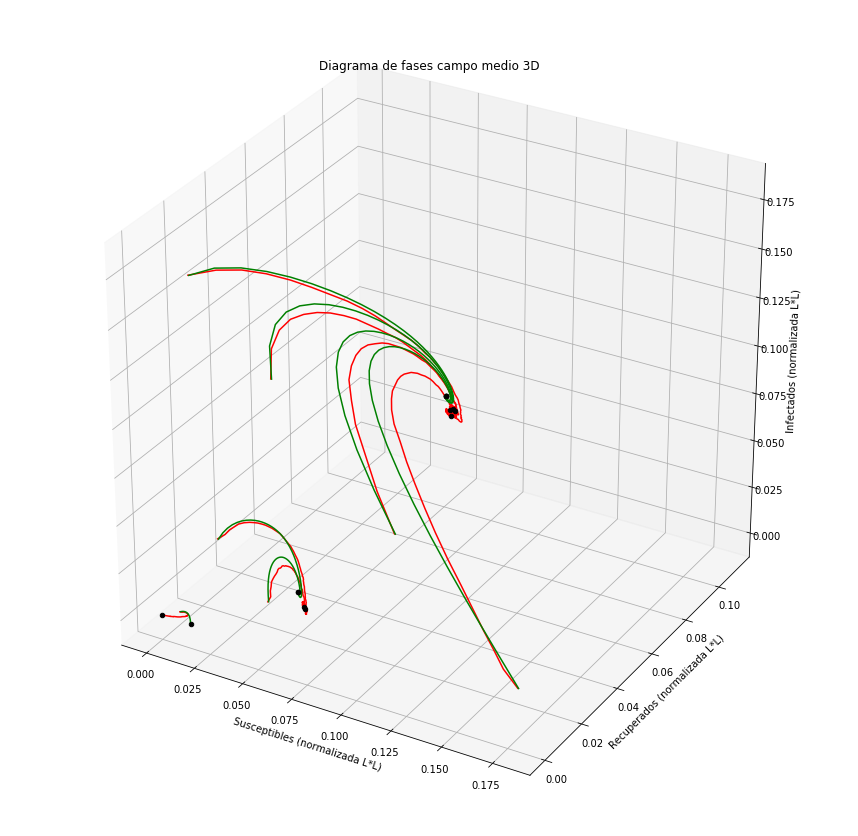

```python
from math import *
import random


Cs = [0.18,0.12,0.06,0.02,0.031,0.056,0.01]
Is = [50,200,350,450,125,62,12]

fig = plt.figure(figsize=(15,15))
ax = fig.gca(projection='3d')

for i in range(0,len(Cs)):
    stats_df = collectData("PeriodicFasesC"+str(Cs[i])+"I"+str(Is[i])+".npy")

    I = stats_df["i_means"]
    S = stats_df["s_means"]
    R = stats_df["r_means"]
    ax.scatter(S[-1],R[-1],I[-1], color='k')
    ax.plot(S,R,I,color='r')


L = 50
C = 0.2
a = pr
b = ps

radio = ((L*L*C)/2 - 1)
n_sims = 4
time_sim = 600

R = [0]
n = 4

S_iniciales = [0.18,0.12,0.06,0.02,0.031,0.056,0.01]
I_iniciales = [0.02,0.08,0.14,0.18,0.05,0.025,0.005]



for i in range(len(S_iniciales)):
    S = [S_iniciales[i]]
    I = [I_iniciales[i]]
    R = [0]
    for t in range(0, time_sim):
        S.append(S[t] - S[t]*(1-(1-p*I[t])**4) + b*R[t])

        I.append(I[t] + S[t]*(1-(1-p*I[t])**4) - a*I[t])

        R.append(R[t] + a*I[t] - b*R[t])

    ax.scatter(S[-1],R[-1],I[-1], color='k')
    ax.plot(S,R,I,color='g')
ax.set_xlabel('Susceptibles (normalizada L*L)')
ax.set_ylabel('Recuperados (normalizada L*L)')
ax.set_zlabel('Infectados (normalizada L*L)')
plt.title('Diagrama de fases campo medio 3D')
plt.show()
```

# Diagrama de Fases Variable

```python
nsimulaciones = 100
max_time=600
C=0.2
L=50
p=0.5
pr=0.1
ps=0.05
periodic = False
```

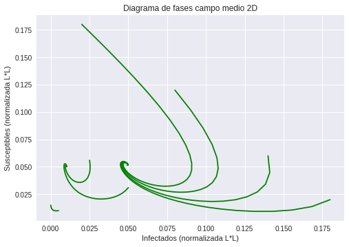

```
Verde: Teorico
```

```python
from matplotlib.pyplot import plot
from modelo import *
import numpy as np
from statsmodels.nonparametric.smoothers_lowess import lowess
import math
from scipy import stats
from IPython.display import HTML, display
from mpl_toolkits.mplot3d import Axes3D

L = 50
C = 0.2
a = pr
b = ps

radio = ((L*L*C)/2 - 1)
n_sims = 4
time_sim = 600

R = [0]
n = 4

S_iniciales = [0.18,0.12,0.06,0.02,0.031,0.056,0.01]
I_iniciales = [0.02,0.08,0.14,0.18,0.05,0.025,0.005]

for i in range(len(S_iniciales)):
  S = [S_iniciales[i]]
  I = [I_iniciales[i]]
  R = [0]
  for t in range(0, time_sim):
      S.append(S[t] - S[t]*(1-(1-p*I[t])**4) + b*R[t])

      I.append(I[t] + S[t]*(1-(1-p*I[t])**4) - a*I[t])

      R.append(R[t] + a*I[t] - b*R[t])


  plt.plot(I,S,color='g')
plt.xlabel('Infectados (normalizada L*L)')
plt.ylabel('Susceptibles (normalizada L*L)')
plt.title('Diagrama de fases campo medio 2D')
plt.show()
print("Verde: Teorico")
```

# Si **Pr** es 0, generación en diferentes casos

## Para Ri = 0

```python
nsimulaciones = 100
max_time=600
C=0.2
L=50
p=0.5
pr=0
ps=0.05
periodic = False
```

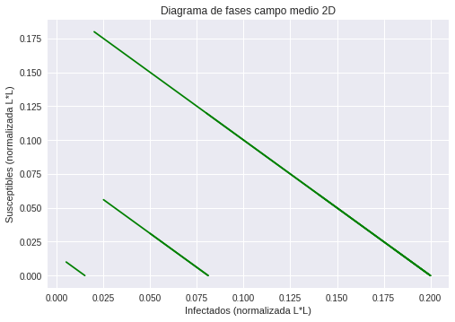

```
Verde: Teorico
```

```python
from matplotlib.pyplot import plot
from modelo import *
import numpy as np
from statsmodels.nonparametric.smoothers_lowess import lowess
import math
from scipy import stats
from IPython.display import HTML, display
from mpl_toolkits.mplot3d import Axes3D

L = 50
C = 0.2
a = pr
b = ps

radio = ((L*L*C)/2 - 1)
n_sims = 4
time_sim = 600

R = [0]
n = 4

S_iniciales = [0.18,0.12,0.06,0.02,0.031,0.056,0.01]
I_iniciales = [0.02,0.08,0.14,0.18,0.05,0.025,0.005]

for i in range(len(S_iniciales)):
  S = [S_iniciales[i]]
  I = [I_iniciales[i]]
  R = [0]
  for t in range(0, time_sim):
      S.append(S[t] - S[t]*(1-(1-p*I[t])**4) + b*R[t])

      I.append(I[t] + S[t]*(1-(1-p*I[t])**4) - a*I[t])

      R.append(R[t] + a*I[t] - b*R[t])


  plt.plot(I,S,color='g')
plt.xlabel('Infectados (normalizada L*L)')
plt.ylabel('Susceptibles (normalizada L*L)')
plt.title('Diagrama de fases campo medio 2D')
plt.show()
print("Verde: Teorico")
```

## Para Ri = 0.11

```python
from matplotlib.pyplot import plot
from modelo import *
import numpy as np
from statsmodels.nonparametric.smoothers_lowess import lowess
import math
from scipy import stats
from IPython.display import HTML, display
from mpl_toolkits.mplot3d import Axes3D

L = 50
C = 0.2
a = pr
b = ps

radio = ((L*L*C)/2 - 1)
n_sims = 4
time_sim = 600

R = [0]
n = 4

S_iniciales = [0.18,0.12,0.06,0.02,0.031,0.056,0.01]
I_iniciales = [0.02,0.08,0.14,0.18,0.05,0.025,0.005]

for i in range(len(S_iniciales)):
  S = [S_iniciales[i]]
  I = [I_iniciales[i]]
  R = [0.11]
  for t in range(0, time_sim):
      S.append(S[t] - S[t]*(1-(1-p*I[t])**4) + b*R[t])

      I.append(I[t] + S[t]*(1-(1-p*I[t])**4) - a*I[t])

      R.append(R[t] + a*I[t] - b*R[t])


  plt.plot(I,S,color='g')
plt.xlabel('Infectados (normalizada L*L)')
plt.ylabel('Susceptibles (normalizada L*L)')
plt.title('Diagrama de fases campo medio 2D')
plt.show()
print("Verde: Teorico")
```

[output not shown]

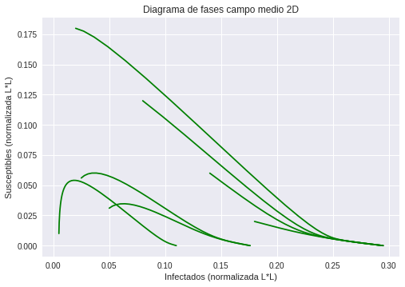

```
Verde: Teorico
```

```python
from matplotlib.pyplot import plot
from modelo import *
import numpy as np
from statsmodels.nonparametric.smoothers_lowess import lowess
import math
from scipy import stats
from IPython.display import HTML, display
from mpl_toolkits.mplot3d import Axes3D

L = 50
C = 0.2
a = pr
b = ps

radio = ((L*L*C)/2 - 1)
n_sims = 4
time_sim = 600

R = [0]
n = 4

S_iniciales = [0.18,0.12,0.06,0.02,0.031,0.056,0.01]
I_iniciales = [0.02,0.08,0.14,0.18,0.05,0.025,0.005]

for i in range(len(S_iniciales)):
  S = [S_iniciales[i]]
  I = [I_iniciales[i]]
  R = [0.095]
  for t in range(0, time_sim):
      S.append(S[t] - S[t]*(1-(1-p*I[t])**4) + b*R[t])

      I.append(I[t] + S[t]*(1-(1-p*I[t])**4) - a*I[t])

      R.append(R[t] + a*I[t] - b*R[t])


  plt.plot(I,S,color='g')
plt.xlabel('Infectados (normalizada L*L)')
plt.ylabel('Susceptibles (normalizada L*L)')
plt.title('Diagrama de fases campo medio 2D')
plt.show()
print("Verde: Teorico")
```

## Diagrama de Fases con Pr << 0.1

```python
pr=0.02
```

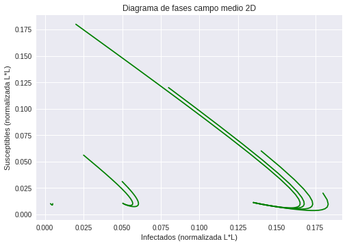

```
Verde: Teorico
```

```python
from matplotlib.pyplot import plot
from modelo import *
import numpy as np
from statsmodels.nonparametric.smoothers_lowess import lowess
import math
from scipy import stats
from IPython.display import HTML, display
from mpl_toolkits.mplot3d import Axes3D

L = 50
C = 0.2
a = pr
b = ps

radio = ((L*L*C)/2 - 1)
n_sims = 4
time_sim = 600

R = [0]
n = 4

S_iniciales = [0.18,0.12,0.06,0.02,0.031,0.056,0.01]
I_iniciales = [0.02,0.08,0.14,0.18,0.05,0.025,0.005]

for i in range(len(S_iniciales)):
  S = [S_iniciales[i]]
  I = [I_iniciales[i]]
  R = [0]
  for t in range(0, time_sim):
      S.append(S[t] - S[t]*(1-(1-p*I[t])**4) + b*R[t])

      I.append(I[t] + S[t]*(1-(1-p*I[t])**4) - a*I[t])

      R.append(R[t] + a*I[t] - b*R[t])


  plt.plot(I,S,color='g')
plt.xlabel('Infectados (normalizada L*L)')
plt.ylabel('Susceptibles (normalizada L*L)')
plt.title('Diagrama de fases campo medio 2D')
plt.show()
print("Verde: Teorico")
```

PRUEBAS

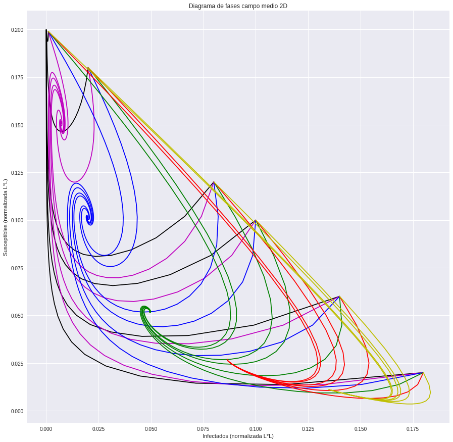

```python
from matplotlib.pyplot import plot
from modelo import *
import numpy as np
from statsmodels.nonparametric.smoothers_lowess import lowess
import math
from scipy import stats
from IPython.display import HTML, display
from mpl_toolkits.mplot3d import Axes3D

L = 50
C = 0.2
a = [0.4,0.3,0.2,0.1,0.05,0.02]
b = ps
col = ['k','m','b','g','r','y',]
radio = ((L*L*C)/2 - 1)
n_sims = 4
time_sim = 600

R = [0]
n = 4
plt.figure(figsize=(15,15))
S_iniciales = [0.199,0.18,0.12,0.06,0.02, 0.1]
I_iniciales = [0.001,0.02,0.08,0.14,0.18, 0.1]
for j in range(len(a)):
  for i in range(len(S_iniciales)):
    S = [S_iniciales[i]]
    I = [I_iniciales[i]]
    R = [0]
    for t in range(0, time_sim):
        S.append(S[t] - S[t]*(1-(1-p*I[t])**4) + b*R[t])

        I.append(I[t] + S[t]*(1-(1-p*I[t])**4) - a[j]*I[t])

        R.append(R[t] + a[j]*I[t] - b*R[t])


    plt.plot(I,S,color=col[j])
plt.xlabel('Infectados (normalizada L*L)')
plt.ylabel('Susceptibles (normalizada L*L)')
plt.title('Diagrama de fases campo medio 2D')
plt.show()
```

```python
from matplotlib.pyplot import plot
from modelo import *
import numpy as np
from statsmodels.nonparametric.smoothers_lowess import lowess
import math
from scipy import stats
from IPython.display import HTML, display
from mpl_toolkits.mplot3d import Axes3D

L = 50
C = [0.9,0.75,0.6,0.45,0.3,0.15]
a = pr
b = ps
col = ['k','m','b','g','r','y',]
n_sims = 4
time_sim = 600

R = [0]
n = 4
fig = plt.figure(figsize=(15,15))
ax = fig.gca(projection='3d')
plt.figure(figsize=(15,15))

for j in range(len(C)):
  for i in range(len(S_iniciales)):
    S = [(L*L*C[j]-1)/(L*L)]
    I = [1/(L*L)]
    R = [0]
    for t in range(0, time_sim):
        S.append(S[t] - S[t]*(1-(1-p*I[t])**4) + b*R[t])

        I.append(I[t] + S[t]*(1-(1-p*I[t])**4) - a*I[t])

        R.append(R[t] + a*I[t] - b*R[t])


    ax.plot(S, I, R, color=col[j])
plt.xlabel('Infectados (normalizada L*L)')
plt.ylabel('Susceptibles (normalizada L*L)')
plt.title('Diagrama de fases campo medio 2D')
plt.show()
```

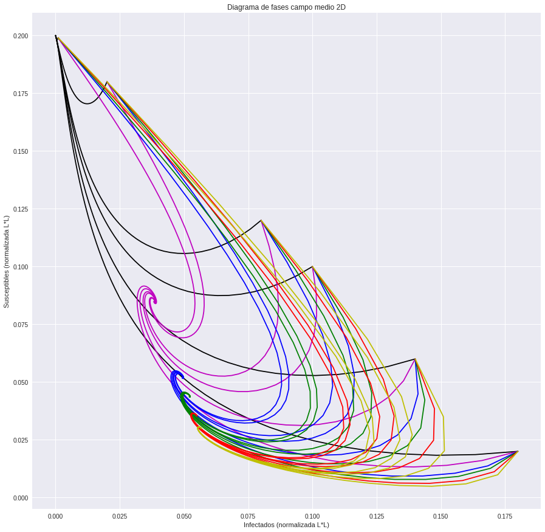

```python
from matplotlib.pyplot import plot
from modelo import *
import numpy as np
from statsmodels.nonparametric.smoothers_lowess import lowess
import math
from scipy import stats
from IPython.display import HTML, display
from mpl_toolkits.mplot3d import Axes3D

L = 50
C = 0.2
a = pr
b = ps
p = [0.1, 0.3, 0.5, 0.6, 0.75, 0.9]
col = ['k','m','b','g','r','y',]
radio = ((L*L*C)/2 - 1)
n_sims = 4
time_sim = 600

R = [0]
n = 4
plt.figure(figsize=(15,15))
S_iniciales = [0.199,0.18,0.12,0.06,0.02, 0.1]
I_iniciales = [0.001,0.02,0.08,0.14,0.18, 0.1]
for j in range(len(p)):
  for i in range(len(S_iniciales)):
    S = [S_iniciales[i]]
    I = [I_iniciales[i]]
    R = [0]
    for t in range(0, time_sim):
        S.append(S[t] - S[t]*(1-(1-p[j]*I[t])**4) + b*R[t])

        I.append(I[t] + S[t]*(1-(1-p[j]*I[t])**4) - a*I[t])

        R.append(R[t] + a*I[t] - b*R[t])


    plt.plot(I,S,color=col[j])
plt.xlabel('Infectados (normalizada L*L)')
plt.ylabel('Susceptibles (normalizada L*L)')
plt.title('Diagrama de fases campo medio 2D')
plt.show()
```

```python
nsimulaciones = 100
max_time=600
C=0.2
L=50
p=0.4
pr=0.1
ps=0.05
periodic = False
```

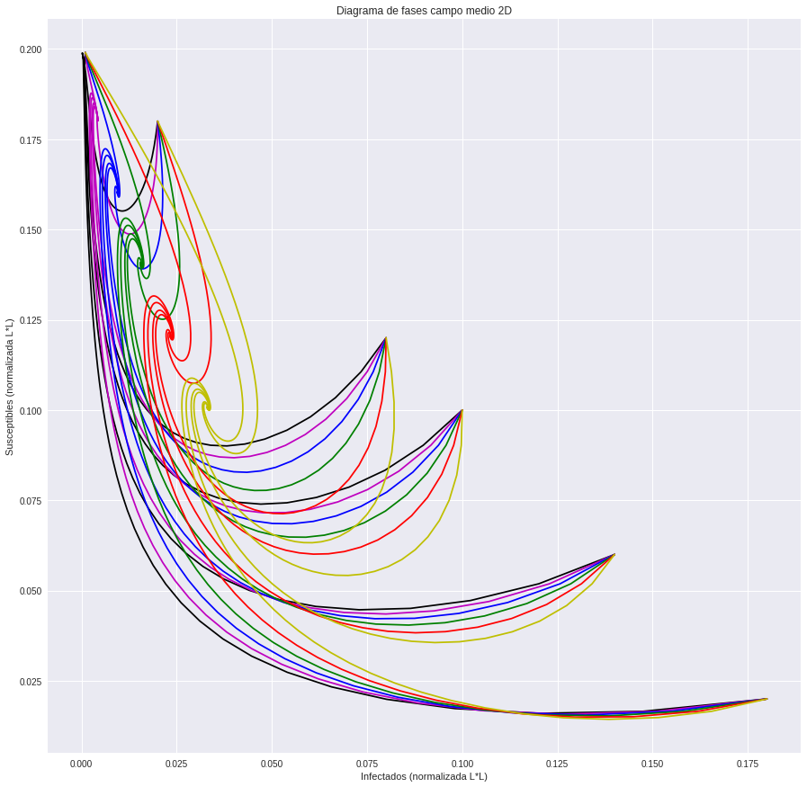

```python
from matplotlib.pyplot import plot
from modelo import *
import numpy as np
from statsmodels.nonparametric.smoothers_lowess import lowess
import math
from scipy import stats
from IPython.display import HTML, display
from mpl_toolkits.mplot3d import Axes3D

L = 50
C = 0.2
a = [0.2, 0.18, 0.16, 0.14, 0.12, 0.1]
b = ps
col = ['k','m','b','g','r','y']
radio = ((L*L*C)/2 - 1)
n_sims = 2
time_sim = 600

R = [0]
n = 2
plt.figure(figsize=(15,15))
S_iniciales = [0.199,0.18,0.12,0.06,0.02, 0.1]
I_iniciales = [0.001,0.02,0.08,0.14,0.18, 0.1]
for j in range(len(a)):
  for i in range(len(S_iniciales)):
    S = [S_iniciales[i]]
    I = [I_iniciales[i]]
    R = [0]
    for t in range(0, time_sim):
        S.append(S[t] - S[t]*(1-(1-p*I[t])**n) + b*R[t])

        I.append(I[t] + S[t]*(1-(1-p*I[t])**n) - a[j]*I[t])

        R.append(R[t] + a[j]*I[t] - b*R[t])


    plt.plot(I,S,color=col[j])
plt.xlabel('Infectados (normalizada L*L)')
plt.ylabel('Susceptibles (normalizada L*L)')
plt.title('Diagrama de fases campo medio 2D')
plt.show()
```